# Social Science Research Methods Analysis Script: Group 4

Thinking about whether income causes democracy

2024-04-29

## Introduction

This script is designed to help you analyse the data on development and democracy for the Social Science Research Methods class at the University of Sydney. You can follow along by running the code in the script! I’ll guide you through the analysis step-by-step.

Ask questions at any time!

You can also use this document in a pre-printed form to follow the class in case there are technical problems with R and RStudio, but it’s much better to follow along in RStudio if you can.

## Prepare the data

```r
# First we need to install some "packages" that enable the data to manipulated, plotted, and examined (not done in this script)


#install.packages("ggplot2")
#install.packages("tidyverse")
#install.packages('Hmisc', repos='http://cran.us.r-project.org')
#install.packages('margins')
#install.packages("ggcorrplot")

# Now we need to load these packages into R
require("tidyverse")
require("Hmisc")
require("margins")
require("ggplot2")
require("ggcorrplot")
```

### Load the data

```r
modernization_data <- read.csv("vdem_group_4.csv")
```

## Getting to know the data

In this section, we explore the structure of the data, including the number of observations, the names of the variables, and summaries of means and range of the variables.

### Questions to think about as you examine the results:

- How many observations do we have?
- What countries do you have in the sample and over what time periods are they observed?
- How are these variables measured? What are the units of measurement?
- Would you measure these in different ways?

```r
# How many observations do we have?
nrow(modernization_data)
```

```
## [1] 3143
```

```r
# What are the names of our columns (i.e) what variables do we have?
names(modernization_data)
```

```
##  [1] "country_name"          "country_id"            "year"
##  [4] "v2x_polyarchy"         "e_gdppc"               "e_pop"
##  [7] "e_total_oil_income_pc" "e_regionpol_6C"        "v2svindep"
## [10] "v2x_polyarchy_lag"     "e_gdppc_lag"
```

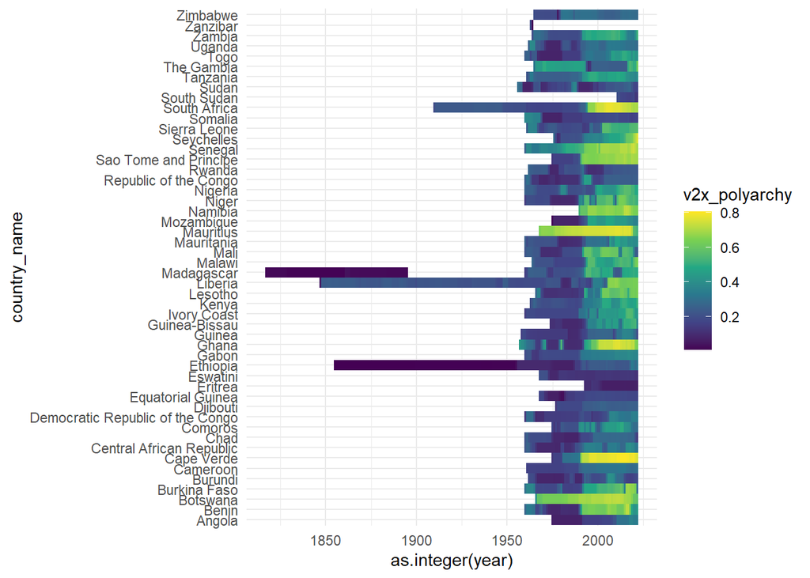

```r
# View the data in an excel-like format
view(modernization_data)

# What countries and years do you have in your sample?
ggplot(modernization_data, aes(y=country_name, x=as.integer(year), fill=v2x_polyarchy)) +
  geom_tile() +
  scale_fill_viridis_c() +
  theme_minimal()
```

## Descriptive statistics

In this section we explore the mean, median, and range of variables in your sample. We also look at how polyarchy and GDP per capita have changed over time in your sample.

### Questions to think about as you examine the results:

- Has this sample been mostly democratic or autocratic?
- Has it been mostly rich or poor?
- What are the key transition points for democracy?

```r
# Summarise all of the variables in the data
summary(modernization_data)
```

```
##  country_name         country_id         year      v2x_polyarchy
##  Length:3143        Min.   :  7.0   Min.   :1817   Min.   :0.010
##  Class :character   1st Qu.: 50.0   1st Qu.:1972   1st Qu.:0.160
##  Mode  :character   Median : 71.0   Median :1990   Median :0.231
##                     Mean   : 84.3   Mean   :1983   Mean   :0.292
##                     3rd Qu.:116.0   3rd Qu.:2006   3rd Qu.:0.411
##                     Max.   :236.0   Max.   :2022   Max.   :0.806
##
##     e_gdppc           e_pop           e_total_oil_income_pc e_regionpol_6C
##  Min.   : 0.286   Min.   :    6.527   Min.   : 0.0000       Min.   :4
##  1st Qu.: 1.331   1st Qu.:  172.888   1st Qu.: 0.0000       1st Qu.:4
##  Median : 1.867   Median :  590.548   Median : 0.0000       Median :4
##  Mean   : 3.277   Mean   : 1232.199   Mean   : 0.1188       Mean   :4
##  3rd Qu.: 2.852   3rd Qu.: 1365.792   3rd Qu.: 0.0000       3rd Qu.:4
##  Max.   :38.393   Max.   :20939.444   Max.   :11.0644       Max.   :4
##  NA's   :147      NA's   :147         NA's   :965
##    v2svindep v2x_polyarchy_lag  e_gdppc_lag
##  Min.   :1   Min.   :0.0100    Min.   : 0.286
##  1st Qu.:1   1st Qu.:0.1590    1st Qu.: 1.331
##  Median :1   Median :0.2300    Median : 1.866
##  Mean   :1   Mean   :0.2885    Mean   : 3.266
##  3rd Qu.:1   3rd Qu.:0.3970    3rd Qu.: 2.844
##  Max.   :1   Max.   :0.8060    Max.   :38.393
##              NA's   :3         NA's   :104
```

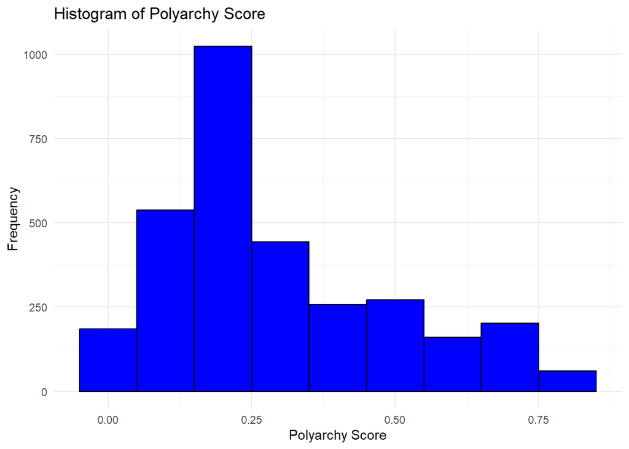

```r
# Plot a histogram of the Polyarchy score using ggplot2
ggplot(modernization_data, aes(x = v2x_polyarchy)) +
  geom_histogram(binwidth = 0.1, fill = "blue", color = "black") +
  labs(title = "Histogram of Polyarchy Score", x = "Polyarchy Score", y = "Frequency") +
  theme_minimal()
```

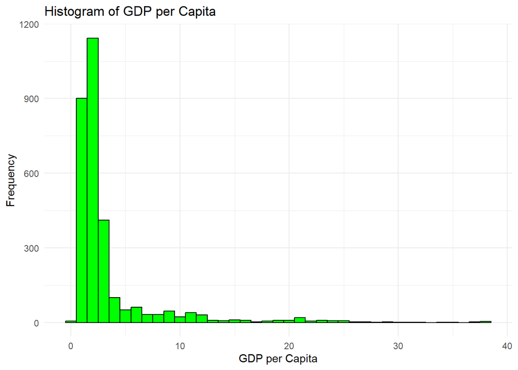

```r
# Plot a histogram of GDP per capita using ggplot2
ggplot(modernization_data, aes(x = e_gdppc)) +
  geom_histogram(binwidth = 1, fill = "green", color = "black") +
  labs(title = "Histogram of GDP per Capita", x = "GDP per Capita", y = "Frequency") +
  theme_minimal()
```

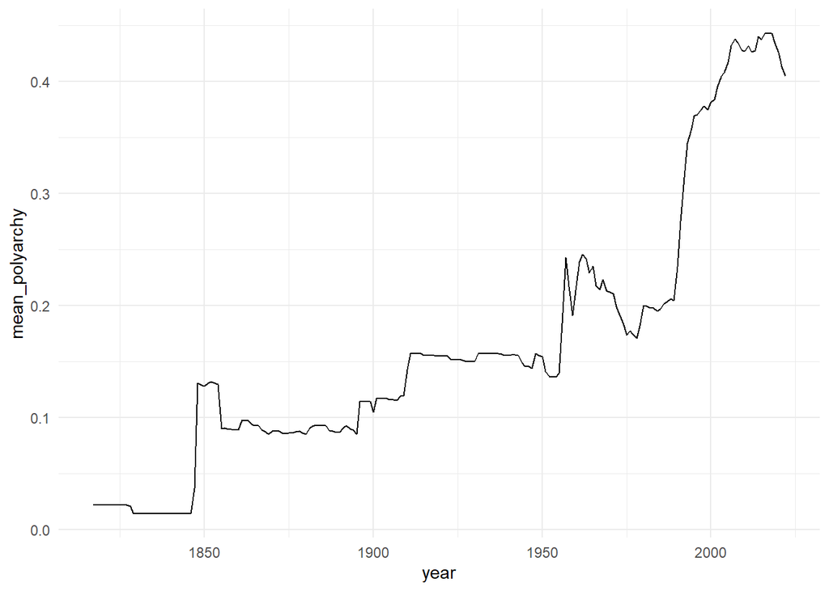

```r
# How has the polyarchy score changed over time in your region?

ggplot(modernization_data %>%
         group_by(year) %>%
         summarise(mean_polyarchy=mean(v2x_polyarchy, na.rm=T)),
       aes(x=year, y=mean_polyarchy)) +
    geom_line() + theme_minimal()
```

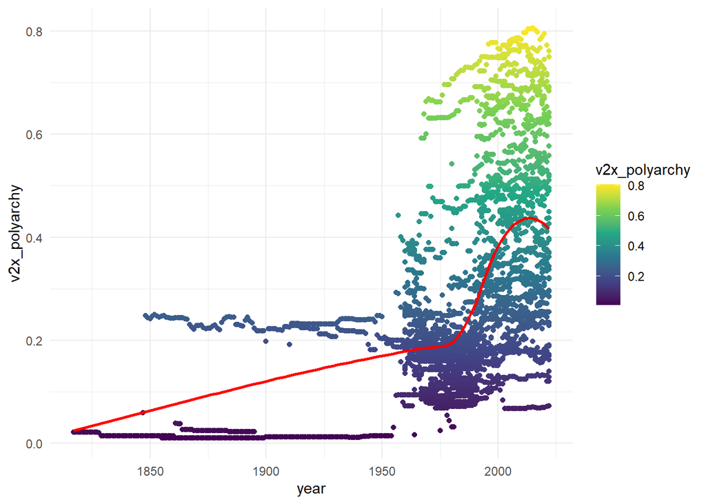

```r
# How has the polyarchy score changed over time in your sample?

ggplot(modernization_data, aes(x=year, y=v2x_polyarchy, colour=v2x_polyarchy)) +
  geom_point() +
  scale_colour_viridis_c() +
  geom_smooth(method = "loess", se = FALSE, color = "red") +
  theme_minimal()
```

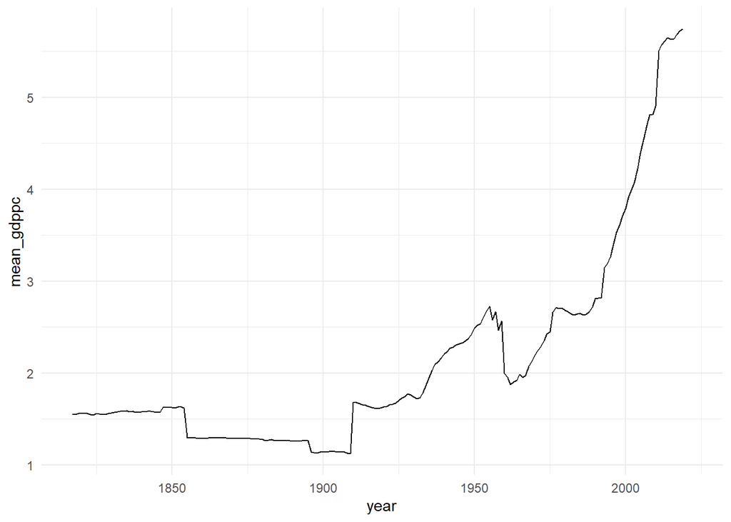

```r
# How has development changed over time in your region?

ggplot(modernization_data %>%
         group_by(year) %>%
         summarise(mean_gdppc=mean(e_gdppc, na.rm=T)),
       aes(x=year, y=mean_gdppc)) +
  geom_line() + theme_minimal()
```

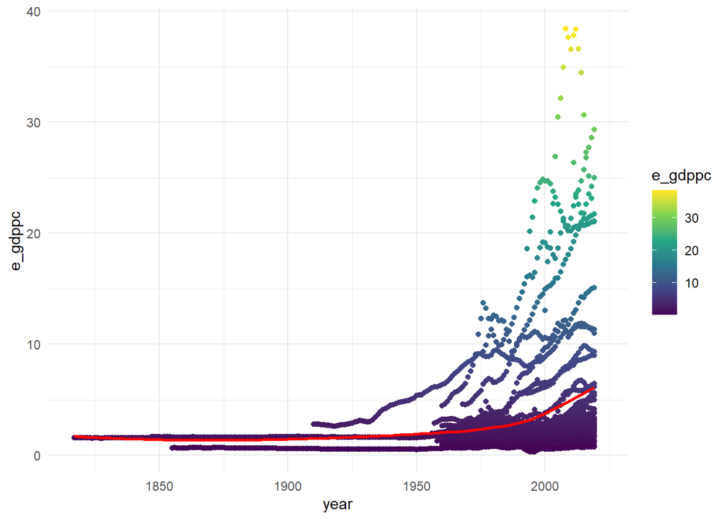

```r
# How has the GDP per capita changed over time in your sample?

ggplot(modernization_data, aes(x=year, y=e_gdppc, colour=e_gdppc)) +
  geom_point() +
  scale_colour_viridis_c() +
  geom_smooth(method = "loess", se = FALSE, color = "red") +
  theme_minimal()
```